# Bacteria-plasmid interactions

Alice Risely

08/02/2022

# 1 Info

Rmarkdown report for the analysis to go with the manuscript “AMR gene presence predicts plasmid network structure in wastewater” by Alice Risely, Thibault Stalder, Benno I. Simmons, Eva M. Top, Angus Buckling, and Dirk Sanders

Data generated by: Stalder et al. “Linking the resistome and plasmidome to the microbiome.” The ISME journal 13.10 (2019): 2437-2446.

Contig processing steps performed under ‘Contig processing’:

1. Remove duplicate (reverse) Hi-C links
2. Assign all contigs to either MAG, putative plasmid (95% probability), or resistance gene contig
3. Remove transposons
4. Remove any Hi-C link involving an unassigned contig (not a MAG, plasmid, or resistance gene)
5. Remove MAG-MAG Hi-C links
6. Cluster plasmid contigs and get metadata on clusters • Filter Hi-C links between putative plasmid contigs (also excluding any resistance contigs) • Exclude any plasmid-plasmid associations that have under 5 links • Generate network for plasmid-plasmid associations and assign clusters • Test which clusters have associations with resistance genes (at least 2 links) • Check total KB length of plasmid clusters for plausability
7. Filter for only MAG-plasmid links
8. Collapse Hi-C links by MAG and plasmid cluster
9. Exclude any singleton links
10. Normalise counts by MAG abundance and plasmid cluster KB length
11. Manipulate data into final MAG-plasmid association count table for analysis

#### 1.0.0.1 Import packages

```r
library(tidyverse)
library(data.table)
library(phyloseq)
library(igraph)
library(network)
library(expss)
library(here)
library(ggnetwork)
library(RColorBrewer)
library(ggvenn)
library(ggrepel)
library(ggpubr)

memory.limit(1000000)
```

```
## [1] 1e+06
```

# 2 Contig processing

### 2.0.1 Import HiC data

- NOT RUN
- First few basic filtering steps are skipped as they take a lot of RAM.
- These include filtering out links that are duplicates and between the same contigs.

```r
### import association table

WW_links <- read.delim(here("DATA","WW_links.txt"), header=FALSE)
head(WW_links)
dim(WW_links)
length(unique(WW_links$V1))


WW_links_DT<-as.data.table(WW_links) # convert to data table
dim(WW_links_DT)
head(WW_links_DT)

rm(WW_links)
```

### 2.0.2 Remove duplicates

```r
# remove contigs attached to themselves

WW_links_DT$self_link<-WW_links_DT$V1 == WW_links_DT$V2
WW_links_DT2<-subset(WW_links_DT, self_link == F)
dim(WW_links_DT2)


## remove duplicates

WW_links_filt2<-WW_links_DT2 %>%
  group_by(grp = paste(pmax(V1, V2), pmin(V1, V2), sep = "_")) %>%
  slice(1) %>%
  ungroup() %>%
  select(-grp)

dim(WW_links_filt2)
```

- Now import pre-filtered HiC links dataframe, called “WW_links_filt2”
- All steps from this point largely involve filtering this dataset of noise so that by the end, only meaningful links remain for analysis

```r
# import dataset where reverse dulplicates have been excluded, as well as any contigs attached to themselves.

setwd("C:/Users/risel/Dropbox/Sommer postdoc/Plasmid project/PlasmidProjectAnalysis/Updated analysis2")
WW_links_filt2<-readRDS("DATA/WW_links_filt.RDS")

head(WW_links_filt2)
```

| V1 | V2 | V3 | self_link |
| --- | --- | --- | --- |
| k141_1000386 | k141_1000196 | 1 | FALSE |
| k141_1000616 | k141_1000543 | 1 | FALSE |
| k141_1000630 | k141_1000774 | 1 | FALSE |
| k141_1000590 | k141_1000833 | 3 | FALSE |
| k141_1000728 | k141_1001032 | 1 | FALSE |
| k141_1001172 | k141_1000706 | 1 | FALSE |

```r
dim(WW_links_filt2) # 28 million rows
```

```
## [1] 28111659        4
```

### 2.0.3 Import MAG contigs

- Import list of MAG contigs

```r
setwd(here("DATA", "MAGS"))

myfiles<-list.files()
myfiles[1:5]
```

```
## [1] "bin_1.fasta"   "bin_10.fasta"  "bin_100.fasta" "bin_101.fasta"
## [5] "bin_102.fasta"
```

```r
dataFiles <- lapply(myfiles, read.table)
myfiles<-str_remove(myfiles, ".fasta") # remove 'fasta' string

length(dataFiles) #379 MAGs
```

```
## [1] 379
```

```r
#change names
names(dataFiles)<-myfiles

### loop to extract contigs per cluster data

mag_list<-list()

for (i in 1:length(myfiles)){

  cluster_x<-dataFiles[[i]]
  selectedRows <- cluster_x[grep(">k141_", cluster_x$V1), ]
  contigs<-substring(selectedRows, 2)

  df<-data.frame(contigs)
  df$cluster<-myfiles[i]

  mag_list[[i]]<-df
}

names(mag_list)<-myfiles
mag_data<-do.call(rbind, mag_list)
mag_assignment<-mag_data
length(unique(mag_assignment$contigs))
```

```
## [1] 61669
```

```r
head(mag_assignment)
```

|  | contigs | cluster |
| --- | --- | --- |
| bin_1.1 | k141_2653614 | bin_1 |
| bin_1.2 | k141_3214329 | bin_1 |
| bin_1.3 | k141_565227 | bin_1 |
| bin_1.4 | k141_3071372 | bin_1 |
| bin_1.5 | k141_3655959 | bin_1 |
| bin_1.6 | k141_1100623 | bin_1 |

```r
mag_list <- as.character(mag_assignment$contigs)

setwd("C:/Users/risel/Dropbox/Sommer postdoc/Plasmid project/PlasmidProjectAnalysis/Updated analysis2")
```

### 2.0.4 Import predited plasmid IDs

- Import results from PlasClass

```r
plasmids_df <- read.delim(here("DATA","plasclass_all_contigs.tsv"), header=FALSE)

names(plasmids_df)<-c("contig_id", "Probability")
head(plasmids_df)
```

|  | contig_id | Probability |
| --- | --- | --- |
| 1 | k141_7 | 0.12272286 |
| 2 | k141_8 | 0.39145121 |
| 3 | k141_9 | 0.48129818 |
| 4 | k141_10 | 0.13149949 |
| 5 | k141_11 | 0.05343254 |
| 6 | k141_12 | 0.31421913 |

```r
dim(plasmids_df)
```

```
## [1] 3627876       2
```

```r
## plasmids = contigs that are 95% likely to be plasmids

plasmids_df$PlasClassHit<-plasmids_df$Probability >0.95 # FLEXIBLE PARAMETER

table(plasmids_df$PlasClassHit) #204,933 plasmid contigs
```

```
##
##   FALSE    TRUE
## 3422943  204933
```

```r
## generate list of plasmids

plasmid_assignment<-subset(plasmids_df, PlasClassHit == TRUE)
head(plasmid_assignment)
```

|  | contig_id | Probability | PlasClassHit |
| --- | --- | --- | --- |
| 8 | k141_14 | 0.9902552 | TRUE |
| 12 | k141_18 | 0.9984381 | TRUE |
| 13 | k141_19 | 0.9728508 | TRUE |
| 26 | k141_32 | 0.9963329 | TRUE |
| 30 | k141_36 | 0.9586086 | TRUE |
| 67 | k141_73 | 0.9950134 | TRUE |

```r
plasmid_list<-as.character(plasmid_assignment$contig_id)
```

### 2.0.5 Import transposon list

```r
transposons <- read.delim(here("DATA","ISfinder_best_match_transposons.csv"), header=TRUE, sep = ",")

dim(transposons)
```

```
## [1] 123748     13
```

```r
head(transposons)
```

|  | contig | sseqid | pident | length | mismatch | gapopen | qstart | qend | sstart | send | evalue | bitscore | database |
| --- | --- | --- | --- | --- | --- | --- | --- | --- | --- | --- | --- | --- | --- |
| 1 | k141_32 | ISMae28 | 58.000 | 50 | 21 | 0 | 3 | 52 | 1 | 50 | 1.18e-14 | 63.2 | ISfinder |
| 2 | k141_36 | ISUnCu2 | 66.667 | 102 | 34 | 0 | 1 | 102 | 193 | 294 | 2.00e-43 | 144.0 | ISfinder |
| 3 | k141_123 | ISAli6 | 81.250 | 224 | 42 | 0 | 1 | 224 | 26 | 249 | 1.41e-132 | 376.0 | ISfinder |
| 4 | k141_224 | ISVer2 | 56.780 | 118 | 49 | 2 | 24 | 139 | 235 | 352 | 4.08e-40 | 135.0 | ISfinder |
| 5 | k141_247 | ISPvu1 | 96.667 | 90 | 3 | 0 | 1 | 90 | 450 | 539 | 2.79e-59 | 187.0 | ISfinder |
| 6 | k141_260 | ISPst8 | 94.483 | 145 | 8 | 0 | 1 | 145 | 47 | 191 | 1.42e-99 | 281.0 | ISfinder |

```r
transposon_list<-as.character(transposons$contig)
```

### 2.0.6 Import resistance gene list

```r
# import AMR gene data
amr_genes <- read.delim(here("DATA","amr_contigs_plassclass_and_plasflow.tsv"))
amr_genes <-amr_genes[,c("contig", "Gene.symbol", "Sequence.name", "Element.type", "Element.subtype")]

head(amr_genes)
```

|  | contig | Gene.symbol | Sequence.name | Element.type | Element.subtype |
| --- | --- | --- | --- | --- | --- |
| 1 | k141_2087656 | blaAER | AER family class A beta-lactamase | AMR | AMR |
| 2 | k141_512049 | bla | class A beta-lactamase | AMR | AMR |
| 3 | k141_1007910 | tet(M) | tetracycline resistance ribosomal protection protein Tet(M) | AMR | AMR |
| 4 | k141_1015460 | tet(40) | tetracycline efflux MFS transporter Tet(40) | AMR | AMR |
| 5 | k141_1038765 | blaFOX | FOX family cephalosporin-hydrolyzing class C beta-lactamase | AMR | AMR |
| 6 | k141_1039329 | aadA11 | ANT(3'')-Ia family aminoglycoside nucleotidyltransferase AadA11 | AMR | AMR |

```r
table(amr_genes$Element.type)
```

```
##
##       AMR    STRESS VIRULENCE
##       266       174         7
```

```r
table(amr_genes$Element.subtype)
```

```
##
##      ACID       AMR   BIOCIDE      HEAT     METAL VIRULENCE
##         2       266        17        26       129         7
```

### 2.0.7 Summarize contig assigments with Venn Diagram

[figure not shown]

```r
## generate list of all unique contigs

allContigs<-c(unique(WW_links_filt2$V1), unique(WW_links_filt2$V2))
allContigs<-unique(allContigs)

mag_list2<- mag_list[mag_list%in%allContigs]
plasmid_list2<- plasmid_list[plasmid_list%in%allContigs]
transposon_list2<- transposon_list[transposon_list%in%allContigs]
resistance_list2<- amr_genes$contig[amr_genes$contig%in%allContigs]


x <- list(
  MAGs = mag_list2,
  Plasmids = plasmid_list2,
  Transposons = transposon_list2,
  Resistance = resistance_list2
  )

ggvenn(
  x,
  fill_color = c("#0073C2FF", "#EFC000FF", "#868686FF", "#CD534CFF"),
  stroke_size = 0.5, set_name_size = 4
  )+ggtitle("Plasmid 90% threshold")
```

### 2.0.8 Remove links that involve an unidentified contigs

- Assign all contigs to whether they are a MAG, Plasmid, Transposon, or resistance gene.

```r
allContigs_df<-data.frame(allContigs)
head(allContigs_df)
```

|  | allContigs |
| --- | --- |
| 1 | k141_1000386 |
| 2 | k141_1000616 |
| 3 | k141_1000630 |
| 4 | k141_1000590 |
| 5 | k141_1000728 |
| 6 | k141_1001172 |

```r
names(allContigs_df)<-"Contig"

allContigs_df$MAG<- allContigs_df$Contig %in% mag_list
allContigs_df$Plasmid<- allContigs_df$Contig %in% plasmid_list
allContigs_df$Transposon<- allContigs_df$Contig %in% transposon_list
allContigs_df$Resistance<- allContigs_df$Contig %in% amr_genes$contig

#head(allContigs_df)

allContigs_df$Remove<- allContigs_df$MAG==F & allContigs_df$Plasmid==F & allContigs_df$Transposon==F & allContigs_df$Resistance==F

#head(allContigs_df)

table(allContigs_df$Remove)
```

```
##
##   FALSE    TRUE
##  276757 2414871
```

```r
allContigs_filt<-subset(allContigs_df, Remove == F)

head(allContigs_filt)
```

|  | Contig | MAG | Plasmid | Transposon | Resistance | Remove |
| --- | --- | --- | --- | --- | --- | --- |
| 8 | k141_1000499 | FALSE | FALSE | TRUE | FALSE | FALSE |
| 17 | k141_1002120 | TRUE | FALSE | FALSE | FALSE | FALSE |
| 18 | k141_1002222 | FALSE | FALSE | TRUE | FALSE | FALSE |
| 25 | k141_1002574 | FALSE | TRUE | FALSE | FALSE | FALSE |
| 28 | k141_1001824 | TRUE | FALSE | FALSE | FALSE | FALSE |
| 36 | k141_100327 | FALSE | TRUE | FALSE | FALSE | FALSE |

- Remove links from HiC links dataframe that are not identified as anything.
- Because we are not interested in these.

```r
WW_links_filt2$Keep<- WW_links_filt2$V1 %in% allContigs_filt$Contig & WW_links_filt2$V2 %in% allContigs_filt$Contig

table(WW_links_filt2$Keep)
```

```
##
##    FALSE     TRUE
## 25537145  2574514
```

```r
WW_links_filt3<-subset(WW_links_filt2, Keep == T)

head(WW_links_filt3)
```

| V1 | V2 | V3 | self_link | Keep |
| --- | --- | --- | --- | --- |
| k141_1001824 | k141_1002846 | 1 | FALSE | TRUE |
| k141_100327 | k141_1000981 | 1 | FALSE | TRUE |
| k141_1001481 | k141_100343 | 1 | FALSE | TRUE |
| k141_1003761 | k141_1001350 | 1 | FALSE | TRUE |
| k141_1005702 | k141_100391 | 3 | FALSE | TRUE |
| k141_1005521 | k141_10058 | 2 | FALSE | TRUE |

### 2.0.9 Remove transposons

- Remove any links that involve a transposon

```r
WW_links_filt3$Transposon <- WW_links_filt3$V1 %in% transposon_list | WW_links_filt3$V2 %in% transposon_list

table(WW_links_filt3$Transposon)
```

```
##
##   FALSE    TRUE
## 1322941 1251573
```

```r
WW_links_filt4<- subset(WW_links_filt3, Transposon == F)

dim(WW_links_filt4) # 1.3 million rows
```

```
## [1] 1322941       6
```

```r
head(WW_links_filt4)
```

| V1 | V2 | V3 | self_link | Keep | Transposon |
| --- | --- | --- | --- | --- | --- |
| k141_1001824 | k141_1002846 | 1 | FALSE | TRUE | FALSE |
| k141_100327 | k141_1000981 | 1 | FALSE | TRUE | FALSE |
| k141_1001481 | k141_100343 | 1 | FALSE | TRUE | FALSE |
| k141_1003761 | k141_1001350 | 1 | FALSE | TRUE | FALSE |
| k141_1005702 | k141_100391 | 3 | FALSE | TRUE | FALSE |
| k141_1005840 | k141_1004892 | 3 | FALSE | TRUE | FALSE |

- So far removed:links that are 1) duplicates, 2) contigs attached to themselves, 3) involve transposons, 4) involve any unidentifiable contigs (not mags/plasmids/AMR, etc)

### 2.0.10 Venn diagram after filtering transposons

```r
## list of contigs left
allContigs<-c(unique(WW_links_filt4$V1), unique(WW_links_filt4$V2))
allContigs<-unique(allContigs)
length(allContigs)
```

```
## [1] 108487
```

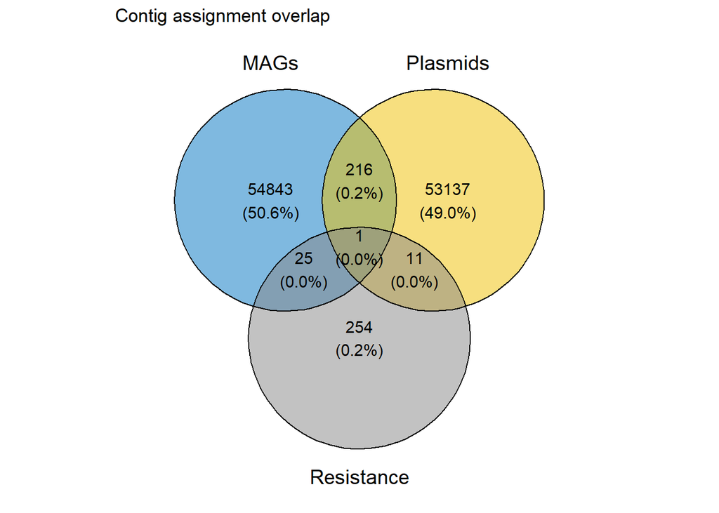

```r
### venn diagram

mag_list2<- mag_list[mag_list%in%allContigs]
plasmid_list2<- plasmid_list[plasmid_list%in%allContigs]
resistance_list2<- amr_genes$contig[amr_genes$contig%in%allContigs]


x <- list(
  MAGs = mag_list2,
  Plasmids = plasmid_list2,
  Resistance = resistance_list2
  )

ggvenn(
  x,
  fill_color = c("#0073C2FF", "#EFC000FF", "#868686FF", "#CD534CFF"),
  stroke_size = 0.5, set_name_size = 5, text_size = 4
  )+ggtitle("Contig assignment overlap")
```

### 2.0.11 Assign remaining contigs to either MAG, plasmid, or resistance gene

```r
allContigs_df<-data.frame(allContigs)
#head(allContigs_df)
names(allContigs_df)<-"Contig"

allContigs_df$MAG<- allContigs_df$Contig %in% mag_list
allContigs_df$Plasmid<- allContigs_df$Contig %in% plasmid_list
allContigs_df$Resistance<- allContigs_df$Contig %in% amr_genes$contig

head(allContigs_df)
```

|  | Contig | MAG | Plasmid | Resistance |
| --- | --- | --- | --- | --- |
| 1 | k141_1001824 | TRUE | FALSE | FALSE |
| 2 | k141_100327 | FALSE | TRUE | FALSE |
| 3 | k141_1001481 | TRUE | FALSE | FALSE |
| 4 | k141_1003761 | TRUE | FALSE | FALSE |
| 5 | k141_1005702 | TRUE | FALSE | FALSE |
| 6 | k141_1005840 | TRUE | FALSE | FALSE |

```r
table(allContigs_df$MAG)
```

```
##
## FALSE  TRUE
## 53402 55085
```

```r
table(allContigs_df$Plasmid)
```

```
##
## FALSE  TRUE
## 55122 53365
```

```r
table(allContigs_df$Resistance)
```

```
##
##  FALSE   TRUE
## 108196    291
```

```r
# final assignment
allContigs_df$Assignment <- ifelse(allContigs_df$Plasmid == TRUE, "PLASMID", "MAG")
allContigs_df$Assignment <- ifelse(allContigs_df$Resistance == TRUE, "AMR", allContigs_df$Assignment)

table(allContigs_df$Assignment)
```

```
##
##     AMR     MAG PLASMID
##     291   54843   53353
```

### 2.0.12 Add contig assignment to links DF

```r
WW_links_filt4$contig1_assignment <- vlookup(WW_links_filt4$V1, allContigs_df, lookup_column = "Contig", result_column = "Assignment")

WW_links_filt4$contig2_assignment <- vlookup(WW_links_filt4$V2, allContigs_df, lookup_column = "Contig", result_column = "Assignment")

head(WW_links_filt4)
```

| V1 | V2 | V3 | self_link | Keep | Transposon | contig1_assignment | contig2_assignment |
| --- | --- | --- | --- | --- | --- | --- | --- |
| k141_1001824 | k141_1002846 | 1 | FALSE | TRUE | FALSE | MAG | MAG |
| k141_100327 | k141_1000981 | 1 | FALSE | TRUE | FALSE | PLASMID | MAG |
| k141_1001481 | k141_100343 | 1 | FALSE | TRUE | FALSE | MAG | MAG |
| k141_1003761 | k141_1001350 | 1 | FALSE | TRUE | FALSE | MAG | MAG |
| k141_1005702 | k141_100391 | 3 | FALSE | TRUE | FALSE | MAG | MAG |
| k141_1005840 | k141_1004892 | 3 | FALSE | TRUE | FALSE | MAG | MAG |

```r
# remove extra columns
WW_links_filt4<-WW_links_filt4[,c(1,2,3,7,8)]
head(WW_links_filt4)
```

| V1 | V2 | V3 | contig1_assignment | contig2_assignment |
| --- | --- | --- | --- | --- |
| k141_1001824 | k141_1002846 | 1 | MAG | MAG |
| k141_100327 | k141_1000981 | 1 | PLASMID | MAG |
| k141_1001481 | k141_100343 | 1 | MAG | MAG |
| k141_1003761 | k141_1001350 | 1 | MAG | MAG |
| k141_1005702 | k141_100391 | 3 | MAG | MAG |
| k141_1005840 | k141_1004892 | 3 | MAG | MAG |

### 2.0.13 Remove MAG-MAG links

- After removing mag-mag links, we have a HiC links dataframe which includes Mag-plasmid links, plasmid-plasmid links, and plasmid-amr links, and mag-amr links.
- We will need this later for the plasmid clustering process

```r
WW_links_filt5 <- WW_links_filt4[!(WW_links_filt4$contig1_assignment=="MAG" & WW_links_filt4$contig2_assignment=="MAG"),]

head(WW_links_filt5)
```

| V1 | V2 | V3 | contig1_assignment | contig2_assignment |
| --- | --- | --- | --- | --- |
| k141_100327 | k141_1000981 | 1 | PLASMID | MAG |
| k141_1009898 | k141_1009200 | 1 | MAG | PLASMID |
| k141_1011540 | k141_100703 | 1 | PLASMID | MAG |
| k141_1011540 | k141_1011601 | 1 | PLASMID | MAG |
| k141_1012715 | k141_1011201 | 1 | PLASMID | MAG |
| k141_1013087 | k141_1004573 | 1 | MAG | PLASMID |

```r
dim(WW_links_filt5)
```

```
## [1] 179579      5
```

### 2.0.14 Cluster plasmids

- Filter links just between putative plasmid contigs to cluster them

```r
links_plasmids <- subset(WW_links_filt5, contig1_assignment == "PLASMID" & contig2_assignment == "PLASMID")
links_plasmids <- links_plasmids %>% arrange(-V3)
head(links_plasmids, 30)
```

| V1 | V2 | V3 | contig1_assignment | contig2_assignment |
| --- | --- | --- | --- | --- |
| k141_2748245 | k141_357290 | 214 | PLASMID | PLASMID |
| k141_528500 | k141_685189 | 91 | PLASMID | PLASMID |
| k141_1276880 | k141_685189 | 87 | PLASMID | PLASMID |
| k141_1276880 | k141_1298064 | 80 | PLASMID | PLASMID |
| k141_427920 | k141_444881 | 76 | PLASMID | PLASMID |
| k141_1260762 | k141_154670 | 66 | PLASMID | PLASMID |
| k141_1276880 | k141_1742774 | 66 | PLASMID | PLASMID |
| k141_798026 | k141_997289 | 66 | PLASMID | PLASMID |
| k141_528500 | k141_1276880 | 62 | PLASMID | PLASMID |
| k141_2800349 | k141_586415 | 53 | PLASMID | PLASMID |

[output cut: 20 more lines]

```r
WW_links_plasmids_filtered<-subset(links_plasmids, V3 >4)
WW_links_plasmids_filtered<-WW_links_plasmids_filtered[,1:3] # keep only first 3 columns

# remove 33 contigs that are unlikely to be contigs (based on gene content)

gene_content <- read.csv("C:/Users/risel/Dropbox/Sommer postdoc/Plasmid project/PlasmidProjectAnalysis/Updated analysis2/DATA/putative_plasmid_gene_content.csv")
unique(gene_content$remove)
```

```
## [1] ""    "yes"
```

```r
remove_df<-subset(gene_content, remove == "yes")
dim(remove_df)
```

```
## [1] 33 12
```

```r
contigs_remove<-as.character(remove_df$Contig)


WW_links_plasmids_filtered$Remove<- WW_links_plasmids_filtered$V1 %in% contigs_remove | WW_links_plasmids_filtered$V2 %in% contigs_remove

table(WW_links_plasmids_filtered$Remove)
```

```
##
## FALSE  TRUE
##   524    37
```

```r
WW_links_plasmids_filtered<-subset(WW_links_plasmids_filtered, Remove == F)

#############################
#############################
#############################

head(WW_links_plasmids_filtered)
```

| V1 | V2 | V3 | Remove |
| --- | --- | --- | --- |
| k141_2748245 | k141_357290 | 214 | FALSE |
| k141_528500 | k141_685189 | 91 | FALSE |
| k141_1276880 | k141_685189 | 87 | FALSE |
| k141_1276880 | k141_1298064 | 80 | FALSE |
| k141_427920 | k141_444881 | 76 | FALSE |
| k141_1276880 | k141_1742774 | 66 | FALSE |

```r
# convert into network object

igraph_net <- graph.data.frame(WW_links_plasmids_filtered[,c('V1','V2')])

# add number of links the the edge weight

E(igraph_net)$weight<-WW_links_plasmids_filtered$V3

igraph_net<-as.undirected(igraph_net) # make undirected

V(igraph_net)$degree<-igraph::degree(igraph_net) # add degree as a node characteristic

# convert network information into a 2D dataframe for plotting

n<-ggnetwork(igraph_net)
head(n)
```

|  | x | y | name | degree | xend | yend | weight |
| --- | --- | --- | --- | --- | --- | --- | --- |
| 1 | 0.000000000 | 0.4564881 | k141_1768085 | 1 | 0.0096645717 | 0.4549598 | 8 |
| 4 | 0.005559468 | 0.4971719 | k141_2349940 | 1 | 0.0107818364 | 0.5054888 | 5 |
| 6 | 0.007720458 | 0.5467573 | k141_2315219 | 3 | 0.0211625777 | 0.5460756 | 5 |
| 7 | 0.007720458 | 0.5467573 | k141_2315219 | 3 | 0.0004542622 | 0.5379039 | 6 |
| 8 | 0.007720458 | 0.5467573 | k141_2315219 | 3 | 0.0043020141 | 0.5586495 | 6 |
| 9 | 0.009572803 | 0.3992611 | k141_2132353 | 2 | 0.0066626475 | 0.3889605 | 6 |

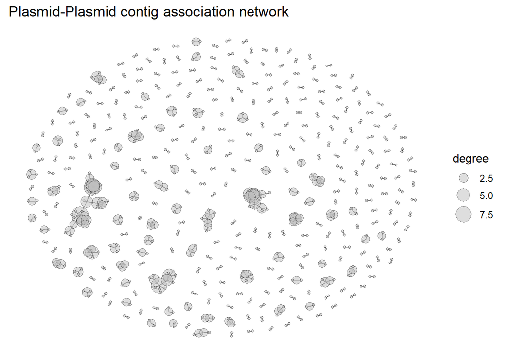

```r
ggplot(n, aes(x = x, y = y, xend = xend, yend = yend)) +
  geom_edges( color = "black", alpha = 0.5) +
  theme_blank()+
  geom_nodes(aes(size = degree), pch = 21, fill = "grey", alpha = 0.5)+
  scale_size(range = c(1,8))+
  ggtitle("Plasmid-Plasmid contig association network")+
  guides(fill = guide_legend(override.aes = list(size = 7)))
```